# Predicting Income Non-Response in a Mozambican Household Survey

Tong Wu

# 📘 Project Overview

- In many social surveys, income related questions have high non-response rates. This project analyzes a data set from Northern Mozambique to explore which demographic and household characteristics predict income non-response. Understanding these factors can inform better survey design in developing countries.

# 🎯 Objectives

- Investigate demographic and infrastructure related predictors of income non-response
- Build logistic regression models, including interaction terms
- Evaluate models with AIC, BIC, Hosmer–Lemeshow test, and ROC-AUC score
- Compare models selected via statistical criteria and cross-validation

# 📦 Data Cleaning & Preparation

- Load data set and create new binary variables for later analysis
- Handle missing values
- Convert variables to factors
- Check whether data is imbalanced

```r
# Load data set
wtp <- read.csv("WTP.csv")

# Produce new variable to show if provide a numerical total income
wtp$INCOME_NONRESPONSE <- ifelse(is.na(wtp$TOTAL_INCOME),1,0)
head(wtp)
```

|  | HH | DAY | TOWN | YEARS | SEX | AGE | STATUS | EDUC | DISABLED | HEAD | SEX_HH | AGE_HH | STATUS_HH | EDUC_HH | DISABLED_HH | AGE_HH_SPOUSE | EDUC_HH_SPOUSE | DISABLED_HH_SPOUSE | HH_SIZE | N_ADULTS | PRIMARY_WS | SUFFICIENT_WATER | TOTAL_TIME | PAY_WATER | TOTAL_COST | ELECTRIC | TOTAL_INCOME | TIME_LENGTH | INCOME_NONRESPONSE |
| --- | --- | --- | --- | --- | --- | --- | --- | --- | --- | --- | --- | --- | --- | --- | --- | --- | --- | --- | --- | --- | --- | --- | --- | --- | --- | --- | --- | --- | --- |
| 1 | 1 | 17 | 0 | 10 | 0 | 27 | 1 | 3 | 0 | 1 | 0 | 27 | 1 | 3 | 0 | NA | NA | NA | 7 | 4 | 6 | 1 | 7 | 1 | 410.4167 | 1 | NA | 35 | 1 |
| 2 | 2 | 18 | 0 | 10 | 0 | 42 | 1 | 4 | 0 | 1 | 0 | 42 | 1 | 4 | 0 | 37 | 4 | 0 | 6 | 3 | 6 | 1 | 18 | 1 | NA | 1 | NA | 45 | 1 |
| 3 | 3 | 18 | 0 | 5 | 0 | 23 | 1 | 4 | 0 | 1 | 0 | 23 | 1 | 4 | 0 | 20 | 4 | 0 | 6 | 3 | NA | 1 | NA | 0 | 0.0000 | 1 | NA | 30 | 1 |
| 4 | 4 | 18 | 0 | 3 | 0 | 39 | 1 | 9999 | 0 | 1 | 0 | 39 | 1 | 9999 | 0 | 22 | 4 | 0 | 5 | 3 | 2 | 1 | 0 | 1 | NA | 1 | NA | 31 | 1 |
| 5 | 5 | 18 | 0 | 11 | 0 | 27 | 2 | 3 | 0 | 1 | 0 | 27 | 2 | 3 | 0 | 18 | 2 | 0 | 6 | 4 | 4 | 1 | 11 | 1 | NA | 1 | NA | 40 | 1 |
| 6 | 6 | 18 | 0 | 3 | 1 | 22 | 1 | 4 | 0 | 0 | 0 | 39 | 1 | 9999 | 0 | 22 | 4 | 0 | 5 | 3 | 2 | 1 | 0 | 1 | NA | 1 | NA | 41 | 1 |

```r
# Table of frequency of outcomes of 0 and 1
table(wtp$INCOME_NONRESPONSE)
```

```
##
##   0   1
## 338 917
```

```r
# Create subset of 9 variables only
wtp.reduced <- wtp[, c("TOWN", "SEX", "AGE", "EDUC", "HEAD", "PAY_WATER", "ELECTRIC", "TIME_LENGTH", "INCOME_NONRESPONSE")]

# Define special codes that refer to missing value and convert those to NA
missing.codes <- c(-1, 9998, 9999)
wtp.cleaned <- wtp.reduced %>%
  mutate(across(everything(), ~ replace(., . %in% missing.codes, NA)))

# Create new data frame that remove missing data NA
wtp.complete <- na.omit(wtp.cleaned)
head(wtp.complete)
```

|  | TOWN | SEX | AGE | EDUC | HEAD | PAY_WATER | ELECTRIC | TIME_LENGTH | INCOME_NONRESPONSE |
| --- | --- | --- | --- | --- | --- | --- | --- | --- | --- |
| 1 | 0 | 0 | 27 | 3 | 1 | 1 | 1 | 35 | 1 |
| 2 | 0 | 0 | 42 | 4 | 1 | 1 | 1 | 45 | 1 |
| 3 | 0 | 0 | 23 | 4 | 1 | 0 | 1 | 30 | 1 |
| 5 | 0 | 0 | 27 | 3 | 1 | 1 | 1 | 40 | 1 |
| 6 | 0 | 1 | 22 | 4 | 0 | 1 | 1 | 41 | 1 |
| 7 | 0 | 1 | 29 | 4 | 0 | 1 | 1 | 38 | 1 |

```r
# Calculate the proportion of observations removed from original data set
removed.rows <- nrow(wtp) - nrow(wtp.complete)
proportion.removed <- round(removed.rows / nrow(wtp),3)
proportion.removed
```

```
## [1] 0.084
```

```r
# Check variables current status and convert those needs to be factor
str(wtp.complete)
```

```
## 'data.frame':    1150 obs. of  9 variables:
##  $ TOWN              : int  0 0 0 0 0 0 0 0 0 0 ...
##  $ SEX               : int  0 0 0 0 1 1 0 1 0 0 ...
##  $ AGE               : int  27 42 23 27 22 29 19 18 30 50 ...
##  $ EDUC              : int  3 4 4 3 4 4 2 2 4 5 ...
##  $ HEAD              : int  1 1 1 1 0 0 1 0 1 1 ...
##  $ PAY_WATER         : int  1 1 0 1 1 1 1 1 1 1 ...
##  $ ELECTRIC          : int  1 1 1 1 1 1 0 1 0 1 ...
##  $ TIME_LENGTH       : int  35 45 30 40 41 38 30 50 35 38 ...
##  $ INCOME_NONRESPONSE: num  1 1 1 1 1 1 0 1 0 0 ...
##  - attr(*, "na.action")= 'omit' Named int [1:105] 4 23 24 46 48 66 71 77 88 114 ...
##   ..- attr(*, "names")= chr [1:105] "4" "23" "24" "46" ...
```

```r
factor.vars <- c("TOWN", "SEX", "EDUC", "HEAD", "PAY_WATER", "ELECTRIC")
wtp.complete[factor.vars] <- lapply(wtp.complete[factor.vars], as.factor)
str(wtp.complete)
```

```
## 'data.frame':    1150 obs. of  9 variables:
##  $ TOWN              : Factor w/ 3 levels "0","1","2": 1 1 1 1 1 1 1 1 1 1 ...
##  $ SEX               : Factor w/ 2 levels "0","1": 1 1 1 1 2 2 1 2 1 1 ...
##  $ AGE               : int  27 42 23 27 22 29 19 18 30 50 ...
##  $ EDUC              : Factor w/ 6 levels "0","1","2","3",..: 4 5 5 4 5 5 3 3 5 6 ...
##  $ HEAD              : Factor w/ 2 levels "0","1": 2 2 2 2 1 1 2 1 2 2 ...
##  $ PAY_WATER         : Factor w/ 2 levels "0","1": 2 2 1 2 2 2 2 2 2 2 ...
##  $ ELECTRIC          : Factor w/ 2 levels "0","1": 2 2 2 2 2 2 1 2 1 2 ...
##  $ TIME_LENGTH       : int  35 45 30 40 41 38 30 50 35 38 ...
##  $ INCOME_NONRESPONSE: num  1 1 1 1 1 1 0 1 0 0 ...
##  - attr(*, "na.action")= 'omit' Named int [1:105] 4 23 24 46 48 66 71 77 88 114 ...
##   ..- attr(*, "names")= chr [1:105] "4" "23" "24" "46" ...
```

# 📝 note:

- The data set contained coded missing values which were converted to NA and removed out, a total about 8.4% of observations were removed. The data is imbalanced, so we would need be careful on the model evaluation metrics.

# 📊 Exploratory Data Analysis (EDA)

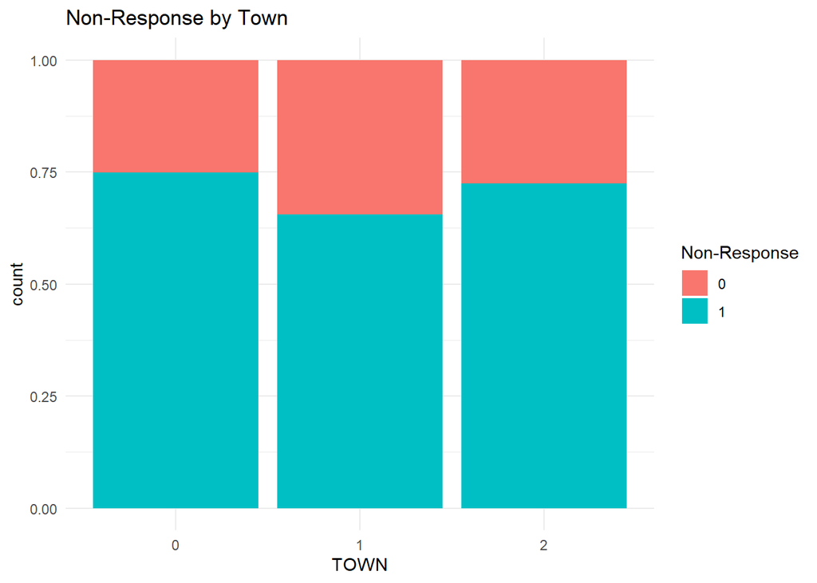

```r
# Generate bar plot to show the income response by town, sex, educ, head, pay water and electric
ggplot(wtp.complete, aes(x = TOWN, fill = as.factor(INCOME_NONRESPONSE))) +
  geom_bar(position = "fill") + labs(title = "Non-Response by Town", fill = "Non-Response") + theme_minimal()
```

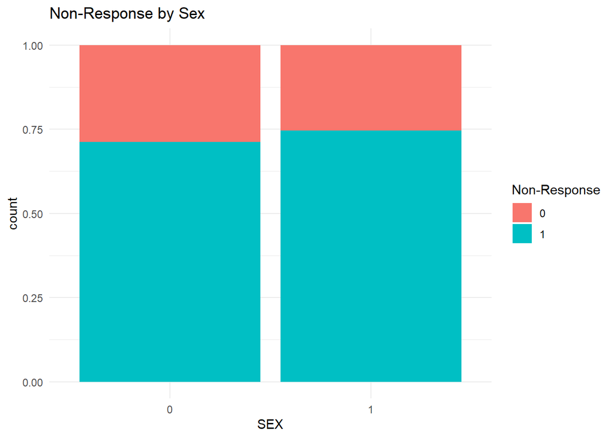

```r
# Generate bar plot to show the income response by sex
ggplot(wtp.complete, aes(x = SEX, fill = as.factor(INCOME_NONRESPONSE))) +
  geom_bar(position = "fill") + labs(title = "Non-Response by Sex", fill = "Non-Response") + theme_minimal()
```

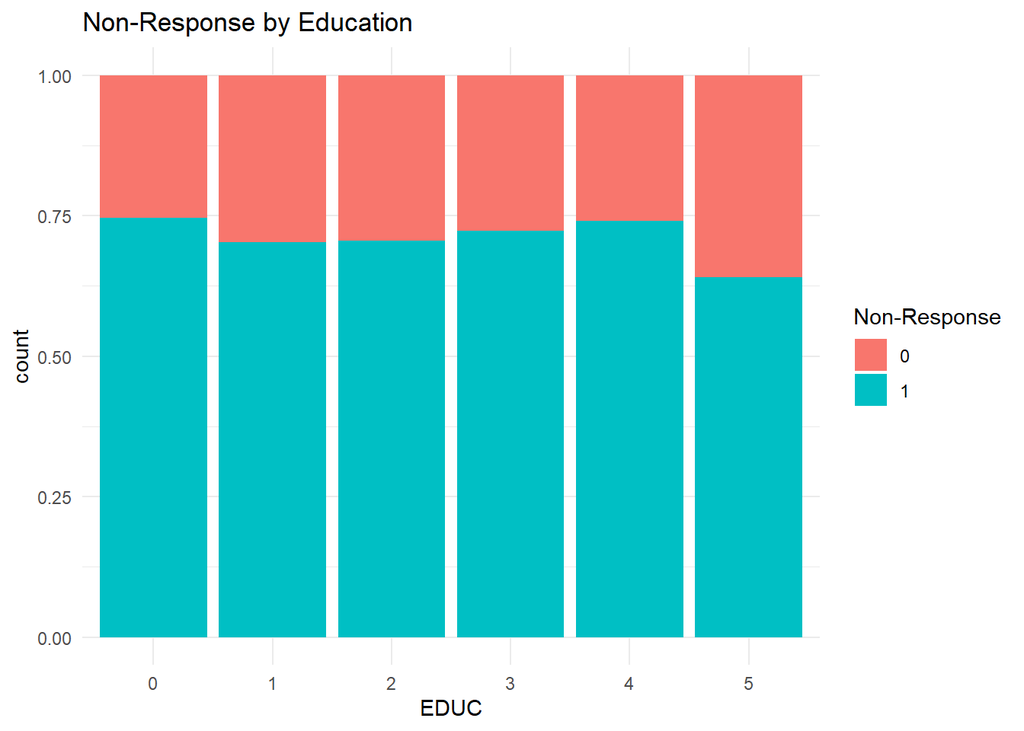

```r
# Generate bar plot to show the income response by educ
ggplot(wtp.complete, aes(x = EDUC, fill = as.factor(INCOME_NONRESPONSE))) +
  geom_bar(position = "fill") + labs(title = "Non-Response by Education", fill = "Non-Response") + theme_minimal()
```

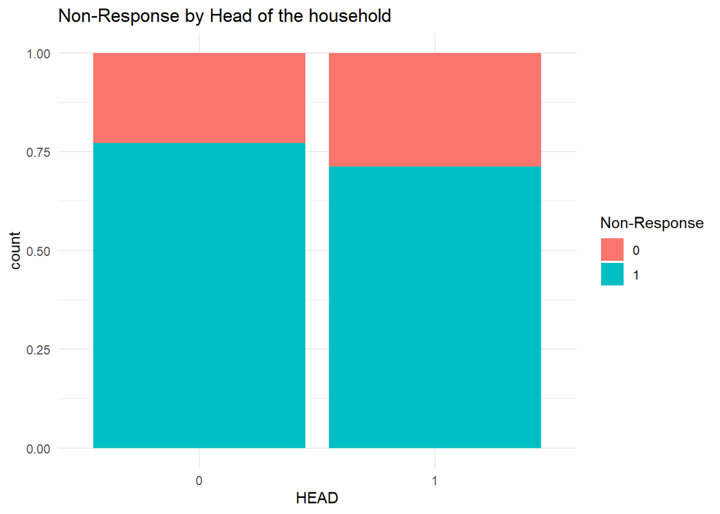

```r
# Generate bar plot to show the income response by head
ggplot(wtp.complete, aes(x = HEAD, fill = as.factor(INCOME_NONRESPONSE))) +
  geom_bar(position = "fill") + labs(title = "Non-Response by Head of the household", fill = "Non-Response") +   theme_minimal()
```

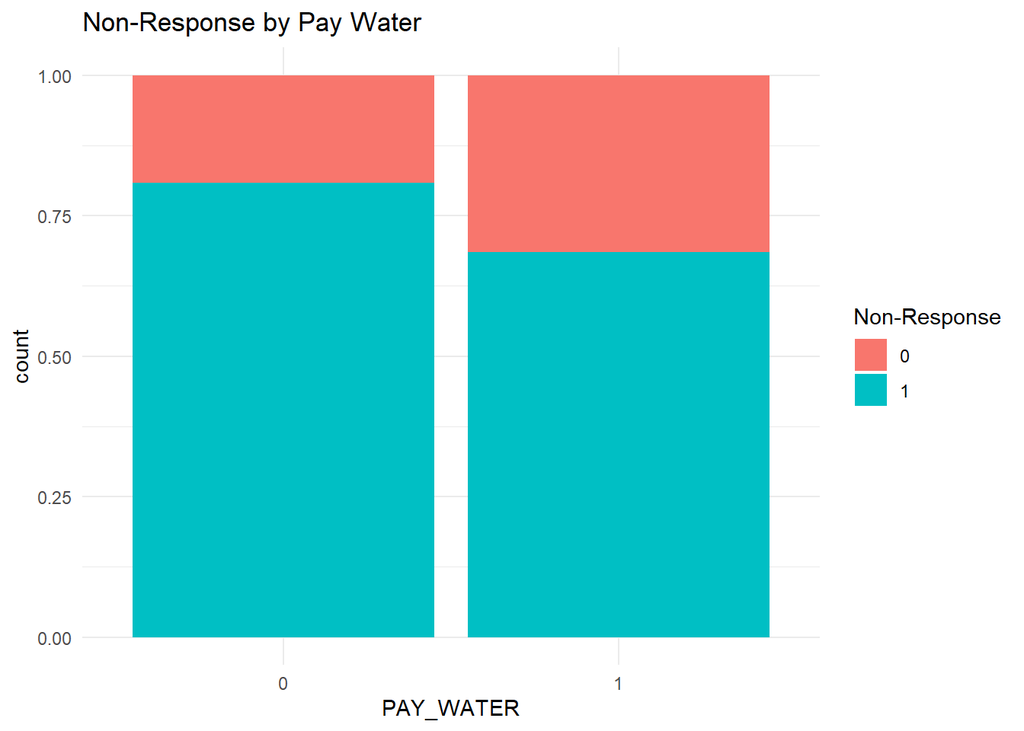

```r
# Generate bar plot to show the income response by pay_water
ggplot(wtp.complete, aes(x = PAY_WATER, fill = as.factor(INCOME_NONRESPONSE))) +
  geom_bar(position = "fill") + labs(title = "Non-Response by Pay Water", fill = "Non-Response") +   theme_minimal()
```

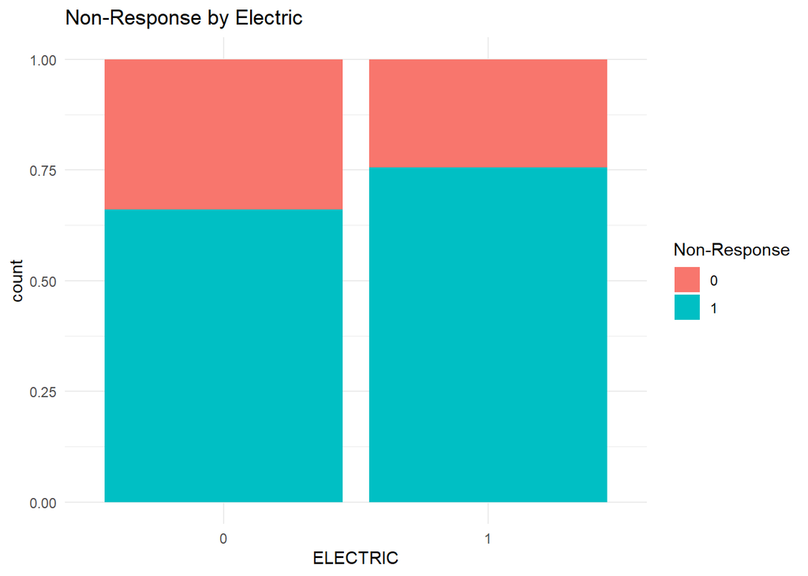

```r
# Generate bar plot to show the income response by electric
ggplot(wtp.complete, aes(x = ELECTRIC, fill = as.factor(INCOME_NONRESPONSE))) +
  geom_bar(position = "fill") + labs(title = "Non-Response by Electric", fill = "Non-Response") +   theme_minimal()
```

# 📝 note:

- According to the plot, we observed higher income non-response rates among households with electricity, not paying for water and among females.

# 🔍 Inferential analysis

- Fit baseline Logistic Regression model
- Model with interaction terms
- Carry out model comparison
- Carry out goodness-of-fit test

```r
# Fit logistic regression model
model <- glm(INCOME_NONRESPONSE ~ TOWN + SEX + AGE + EDUC + HEAD + PAY_WATER + ELECTRIC + TIME_LENGTH, data = wtp.complete, family = "binomial")

# Calculate VIF to check the multicollinearity
model.vif <- vif(model)
vif.value <- round(model.vif, 3)
vif.value
```

```
##              GVIF Df GVIF^(1/(2*Df))
## TOWN        1.606  2           1.126
## SEX         1.908  1           1.381
## AGE         1.385  1           1.177
## EDUC        1.721  5           1.056
## HEAD        1.920  1           1.386
## PAY_WATER   1.049  1           1.024
## ELECTRIC    1.672  1           1.293
## TIME_LENGTH 1.050  1           1.025
```

```r
# Get model summary to see what variable is significant
summary(model)
```

```
##
## Call:
## glm(formula = INCOME_NONRESPONSE ~ TOWN + SEX + AGE + EDUC +
##     HEAD + PAY_WATER + ELECTRIC + TIME_LENGTH, family = "binomial",
##     data = wtp.complete)
##
## Coefficients:
##               Estimate Std. Error z value Pr(>|z|)
## (Intercept)  1.8230804  0.6056877   3.010  0.00261 **
## TOWN1       -0.1747715  0.2218932  -0.788  0.43091
## TOWN2        0.0024712  0.1674661   0.015  0.98823
## SEX1         0.0105611  0.2058455   0.051  0.95908
## AGE          0.0001995  0.0061956   0.032  0.97432
## EDUC1       -0.2611948  0.3354583  -0.779  0.43620
## EDUC2       -0.2622796  0.3585289  -0.732  0.46445
## EDUC3       -0.2248792  0.3527359  -0.638  0.52378
## EDUC4       -0.1905291  0.3459811  -0.551  0.58184
## EDUC5       -0.6680018  0.4743931  -1.408  0.15910
## HEAD1       -0.2829691  0.2635889  -1.074  0.28304
## PAY_WATER1  -0.7493483  0.1625172  -4.611 4.01e-06 ***
## ELECTRIC1    0.5101493  0.1768845   2.884  0.00393 **
## TIME_LENGTH -0.0034916  0.0069994  -0.499  0.61789
## ---
## Signif. codes:  0 '***' 0.001 '**' 0.01 '*' 0.05 '.' 0.1 ' ' 1
##
## (Dispersion parameter for binomial family taken to be 1)
##
##     Null deviance: 1360.0  on 1149  degrees of freedom
## Residual deviance: 1318.6  on 1136  degrees of freedom
## AIC: 1346.6
##
## Number of Fisher Scoring iterations: 4
```

```r
# Fit a model with interactions and produce summary
model.interactions <- glm(INCOME_NONRESPONSE ~ TOWN + SEX + AGE + EDUC + HEAD + PAY_WATER + ELECTRIC + TIME_LENGTH + SEX:PAY_WATER + SEX:ELECTRIC, data = wtp.complete, family = "binomial")
summary(model.interactions)
```

```
##
## Call:
## glm(formula = INCOME_NONRESPONSE ~ TOWN + SEX + AGE + EDUC +
##     HEAD + PAY_WATER + ELECTRIC + TIME_LENGTH + SEX:PAY_WATER +
##     SEX:ELECTRIC, family = "binomial", data = wtp.complete)
##
## Coefficients:
##                   Estimate Std. Error z value Pr(>|z|)
## (Intercept)      1.7068122  0.6189770   2.757  0.00583 **
## TOWN1           -0.2112470  0.2222940  -0.950  0.34196
## TOWN2            0.0071608  0.1681485   0.043  0.96603
## SEX1             0.3450603  0.3881931   0.889  0.37406
## AGE              0.0008467  0.0062175   0.136  0.89168
## EDUC1           -0.2808291  0.3424747  -0.820  0.41222
## EDUC2           -0.2824931  0.3657183  -0.772  0.43986
## EDUC3           -0.2385960  0.3602483  -0.662  0.50777
## EDUC4           -0.1983478  0.3529555  -0.562  0.57414
## EDUC5           -0.6689781  0.4786744  -1.398  0.16224
## HEAD1           -0.2489555  0.2763198  -0.901  0.36760
## PAY_WATER1      -0.5244759  0.1839501  -2.851  0.00436 **
## ELECTRIC1        0.2953953  0.2002597   1.475  0.14020
## TIME_LENGTH     -0.0025280  0.0070445  -0.359  0.71970
## SEX1:PAY_WATER1 -0.9350686  0.3975977  -2.352  0.01868 *
## SEX1:ELECTRIC1   0.7368663  0.3216756   2.291  0.02198 *
## ---
## Signif. codes:  0 '***' 0.001 '**' 0.01 '*' 0.05 '.' 0.1 ' ' 1
##
## (Dispersion parameter for binomial family taken to be 1)
##
##     Null deviance: 1360.0  on 1149  degrees of freedom
## Residual deviance: 1308.8  on 1134  degrees of freedom
## AIC: 1340.8
##
## Number of Fisher Scoring iterations: 4
```

```r
# Carry out likelihood ratio test
model <- glm(INCOME_NONRESPONSE ~ SEX + AGE + EDUC + PAY_WATER + ELECTRIC, data = wtp.complete, family = "binomial")

model.interactions <- glm(INCOME_NONRESPONSE ~ SEX + AGE + EDUC + PAY_WATER + ELECTRIC + SEX:PAY_WATER + SEX:ELECTRIC, data = wtp.complete, family = "binomial")

pander(anova(model, model.interactions, test = "Chisq"))
```

Analysis of Deviance Table

| Resid. Df | Resid. Dev | Df | Deviance | Pr(>Chi) |
| --- | --- | --- | --- | --- |
| 1140 | 1321 | NA | NA | NA |
| 1138 | 1311 | 2 | 9.809 | 0.007412 |

```r
# performance Hosmer-Lemeshow test
hl.5 <- hoslem.test(wtp.complete$INCOME_NONRESPONSE,fitted(model.interactions), g=5)
hl.10 <- hoslem.test(wtp.complete$INCOME_NONRESPONSE,fitted(model.interactions), g=10)
hl.15 <- hoslem.test(wtp.complete$INCOME_NONRESPONSE,fitted(model.interactions), g=15)

# create summary table
hl.results <- data.frame(
  Groups = c(5,10,15),
  Chi_Squared = c(hl.5$statistic, hl.10$statistic, hl.15$statistic),
  DF = c(hl.5$parameter, hl.10$parameter, hl.15$parameter),
  P_value = c(hl.5$p.value, hl.10$p.value, hl.15$p.value)
)

hl.results
```

| Groups | Chi_Squared | DF | P_value |
| --- | --- | --- | --- |
| 5 | 2.560084 | 3 | 0.4645304 |
| 10 | 7.528755 | 8 | 0.4807998 |
| 15 | 12.974895 | 13 | 0.4497528 |

# 📝 note:

- Electricity and Pay_for_water are significant predictors. Multicollinearity is low (VIF < 5).
- The interaction between gender and both PAY_WATER and ELECTRIC is significant, suggesting different response behaviors by gender.
- The interaction model significantly improves fit (p = 0.0074).
- Hosmer–Lemeshow test shows no evidence of poor fit (p > 0.05).

# 🔁 Statistical learning

- Model selection with AIC/BIC
- Cross-validation with AUC and Accuracy

```r
# prepare dataset in format required by bestglm
predictors.for.bestglm <- data.frame(
  TOWN = as.factor(wtp.complete$TOWN),
  SEX = as.factor(wtp.complete$SEX),
  AGE = wtp.complete$AGE,
  EDUC = as.factor(wtp.complete$EDUC),
  HEAD = as.factor(wtp.complete$HEAD),
  PAY_WATER = as.factor(wtp.complete$PAY_WATER),
  ELECTRIC = as.factor(wtp.complete$ELECTRIC),
  TIME_LENGTH = wtp.complete$TIME_LENGTH,
  y = wtp.complete$INCOME_NONRESPONSE)

# find best logistic regression model in terms of AIC
best.logistic.AIC <- bestglm(Xy = predictors.for.bestglm, family = binomial,
                             IC = "AIC", method = "exhaustive")
```

```
## Morgan-Tatar search since family is non-gaussian.
```

```
## Note: factors present with more than 2 levels.
```

```r
# find best logistic regression model in terms of BIC
best.logistic.BIC <- bestglm(Xy = predictors.for.bestglm,family = binomial,
                             IC = "BIC", method = "exhaustive")
```

```
## Morgan-Tatar search since family is non-gaussian.
## Note: factors present with more than 2 levels.
```

```r
best.logistic.AIC$BestModels
```

| TOWN | SEX | AGE | EDUC | HEAD | PAY_WATER | ELECTRIC | TIME_LENGTH | Criterion |
| --- | --- | --- | --- | --- | --- | --- | --- | --- |
| FALSE | FALSE | FALSE | FALSE | TRUE | TRUE | TRUE | FALSE | 1328.258 |
| FALSE | FALSE | FALSE | FALSE | FALSE | TRUE | TRUE | FALSE | 1328.945 |
| FALSE | TRUE | FALSE | FALSE | FALSE | TRUE | TRUE | FALSE | 1329.154 |
| FALSE | FALSE | FALSE | FALSE | TRUE | TRUE | TRUE | TRUE | 1329.938 |
| FALSE | TRUE | FALSE | FALSE | TRUE | TRUE | TRUE | FALSE | 1330.154 |

```r
best.logistic.BIC$BestModels
```

| TOWN | SEX | AGE | EDUC | HEAD | PAY_WATER | ELECTRIC | TIME_LENGTH | Criterion |
| --- | --- | --- | --- | --- | --- | --- | --- | --- |
| FALSE | FALSE | FALSE | FALSE | FALSE | TRUE | TRUE | FALSE | 1339.040 |
| FALSE | FALSE | FALSE | FALSE | TRUE | TRUE | TRUE | FALSE | 1343.401 |
| FALSE | TRUE | FALSE | FALSE | FALSE | TRUE | TRUE | FALSE | 1344.297 |
| FALSE | FALSE | FALSE | FALSE | FALSE | TRUE | TRUE | TRUE | 1345.667 |
| FALSE | FALSE | TRUE | FALSE | FALSE | TRUE | TRUE | FALSE | 1345.826 |

```r
# specify the indices of the variables to be considered
set.seed(0)
names(wtp.complete)
```

```
## [1] "TOWN"               "SEX"                "AGE"
## [4] "EDUC"               "HEAD"               "PAY_WATER"
## [7] "ELECTRIC"           "TIME_LENGTH"        "INCOME_NONRESPONSE"
```

```r
variable.indices <- 1:8

# produce matrix that represents all possible combinations of variables
all.comb <- expand.grid(as.data.frame(matrix(rep(0 : 1, length(variable.indices)), nrow = 2)))[-1,]


# specify the number of folds and repetitions
folds <- 10
reps <- 20

# fire up 75% of cores for parallel processing.
nclust <- makeCluster(detectCores() * 0.75)
registerDoParallel(nclust)

# specify settings for repeated 10-folds cross validation for accuracy
fitControl <- trainControl(
  method = "repeatedcv",
  number = folds,
  repeats = reps,
  seeds = 1 : (folds * reps + 1),
  classProbs = TRUE,
  savePredictions = TRUE
)

# produce accuracy
accuracy <- foreach(i = 1 : nrow(all.comb), .combine = "rbind", .packages = "caret") %dopar%
{
c(i, unlist(train(as.formula(paste("make.names(INCOME_NONRESPONSE) ~",
paste(names(wtp.complete)[variable.indices][all.comb[i,] == 1], collapse = " + "))), data
= wtp.complete, trControl = fitControl, method = "glm", family = "binomial", metric =
"Accuracy")$results[c(2, 4)]))
}

rownames(accuracy) <- NULL
```

```r
# produce AUC
fitControl <- trainControl(
  method = "repeatedcv",
  number = folds,
  repeats = reps,
  seeds = 1 : (folds * reps + 1),
  summaryFunction = twoClassSummary,
  classProbs = TRUE,
  savePredictions = TRUE
)

# Save estimated AUC and standard errors for each set of covariates.
AUC <- foreach(i = 1 : nrow(all.comb), .combine = "rbind", .packages = "caret") %dopar%
{
c(i, unlist(train(as.formula(paste("make.names(INCOME_NONRESPONSE) ~",
paste(names(wtp.complete)[variable.indices][all.comb[i,] == 1], collapse = " + "))), data
= wtp.complete, trControl = fitControl, method = "glm", family = "binomial", metric =
"ROC")$results[c(2, 5)]))
}

rownames(AUC) <- NULL
```

```r
# shut down cores
stopCluster(nclust)
```

```r
# show the optimal models by accuracy
best.acc <- accuracy[which.max(accuracy[, 2]), ]
best.model.acc <- all.comb[best.acc[1], ]
best.model.acc
```

|  | V1 | V2 | V3 | V4 | V5 | V6 | V7 | V8 |
| --- | --- | --- | --- | --- | --- | --- | --- | --- |
| 229 | 0 | 0 | 1 | 0 | 0 | 1 | 1 | 1 |

```r
predictor.names <- c("TOWN", "SEX", "AGE", "EDUC", "HEAD", "PAY_WATER", "ELECTRIC", "TIME_LENGTH")
selected.predictors.acc <- predictor.names[which(as.logical(best.model.acc))]
selected.predictors.acc
```

```
## [1] "AGE"         "PAY_WATER"   "ELECTRIC"    "TIME_LENGTH"
```

```r
# show the optimal models by AUC
best.auc <- AUC[which.max(AUC[,2]),]
best.model.auc <- all.comb[best.auc[1],]
best.model.auc
```

|  | V1 | V2 | V3 | V4 | V5 | V6 | V7 | V8 |
| --- | --- | --- | --- | --- | --- | --- | --- | --- |
| 241 | 0 | 0 | 0 | 0 | 1 | 1 | 1 | 1 |

```r
selected.predictors.auc <- predictor.names[which(as.logical(best.model.auc))]
selected.predictors.auc
```

```
## [1] "HEAD"        "PAY_WATER"   "ELECTRIC"    "TIME_LENGTH"
```

# 📝 note:

- AIC selects HEAD + PAY_WATER + ELECTRIC; BIC selects a simpler model excluding HEAD.
- The optimal model based on accuracy including AGE + PAY_WATER + ELECTRIC + TIME_LENGTH and based on AUC including HEAD + PAY_WATER + ELECTRIC + TIME_LENGTH.
- Since our goal is prediction, we would prefer the out-of-sample performance metric - Accuracy and AUC, as they can tell how well the model will work on future data.
- AUC and Accuracy differ only on whether to include HEAD or AGE, but since AIC including HEAD, we would consider the final model as including HEAD + PAY_WATER + ELECTRIC +TIME_LENGTH.